# 1. Linear Decision Boundaries

Vaakesan Sundrelingam

The purpose of the analysis below is to investigate and visualize the behaviour of linear decision boundaries between multiple classifiers. In order to simplify the scope of the investigation, only the two dimensional case will be considered.

```r
library(knitr)
library(datasets)

data(iris) #using the iris classification dataset
str(iris)
```

```
## 'data.frame':    150 obs. of  5 variables:
##  $ Sepal.Length: num  5.1 4.9 4.7 4.6 5 5.4 4.6 5 4.4 4.9 ...
##  $ Sepal.Width : num  3.5 3 3.2 3.1 3.6 3.9 3.4 3.4 2.9 3.1 ...
##  $ Petal.Length: num  1.4 1.4 1.3 1.5 1.4 1.7 1.4 1.5 1.4 1.5 ...
##  $ Petal.Width : num  0.2 0.2 0.2 0.2 0.2 0.4 0.3 0.2 0.2 0.1 ...
##  $ Species     : Factor w/ 3 levels "setosa","versicolor",..: 1 1 1 1 1 1 1 1 1 1 ...
```

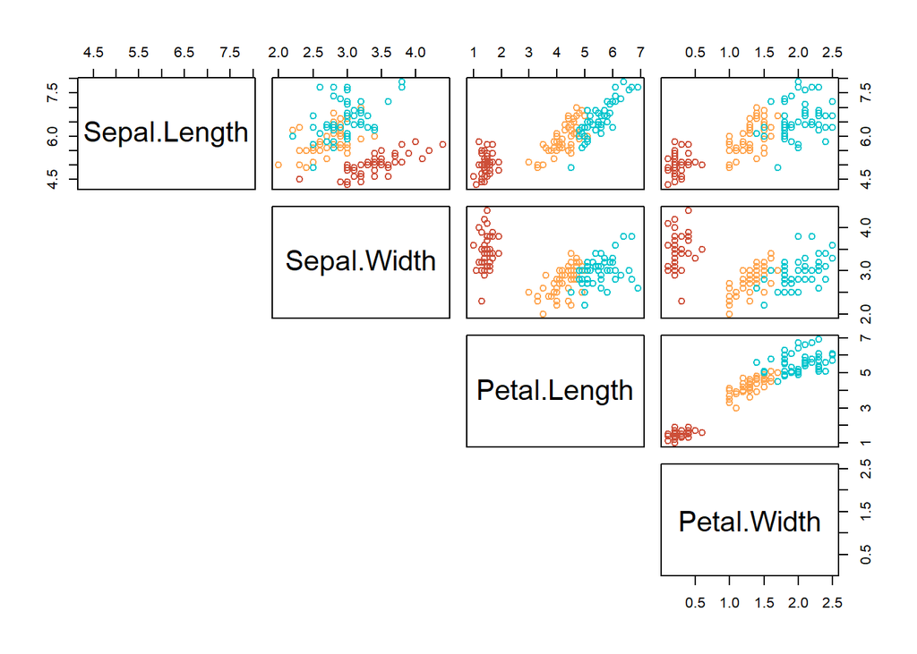

```r
#colouring based on class membership
speciesColour <- ifelse(iris$Species=="setosa", y="tomato3",
                               n=ifelse(iris$Species=="versicolor", y="tan1",
                                        n=ifelse(iris$Species=="virginica", y="turquoise3",
                                                 n="black")))
#correlation plot to determine which variables could pose multicollinearity problems
pairs(iris[-5],col=speciesColour, lower.panel=NULL)
```

The above correlation matrix shows good separation in the classes, except between sepal length and sepal width. There is also a very strong correlation between petal length and petal width. These variables are good candidates for dimensionality reduction.

**1.1. Logistic Regression Decision Boundaries**

I want to visualize a linear decision boundary for these groups. I will limit myself to 2 variables for now (for more straightforward visualization), and use logistic regression to determine the equation for the boundary.

```r
library(nnet)
logitFit <- multinom(Species ~ Sepal.Length + Sepal.Width, data=iris)
logitFit
```

```
## Call:
## multinom(formula = Species ~ Sepal.Length + Sepal.Width, data = iris)
##
## Coefficients:
##            (Intercept) Sepal.Length Sepal.Width
## versicolor   -92.09924     40.40326   -40.58755
## virginica   -105.10096     42.30094   -40.18799
##
## Residual Deviance: 110.425
## AIC: 122.425
```

The equation for the “log odds” looks like this:
$$log\frac{Pr(G=versicolor\:|X=x)}{Pr(G=setosa\:|X=x)}=\beta_{1,0}+\beta_1^T\begin{bmatrix}sepal\:length \\ sepal\:width \end{bmatrix}$$

At the decision boundary, $Pr(G=versicolor|X=x)=Pr(G=setosa|X=x)$ (for a threshold probability of 0.5). Which gives the following:
$$log1=\beta_{1,0}+\begin{bmatrix}\beta_{1,1} & \beta_{1,2}\end{bmatrix}\begin{bmatrix}sepal\:length \\ sepal\:width \end{bmatrix}$$

Simplification and rearrangement gives an equation of a line that can be plotted in R:
$$sepal\:width=-\frac{\beta_{1,0}}{\beta_{1,2}}-\frac{\beta_{1,1}}{\beta_{1,2}}(sepal\:length)$$

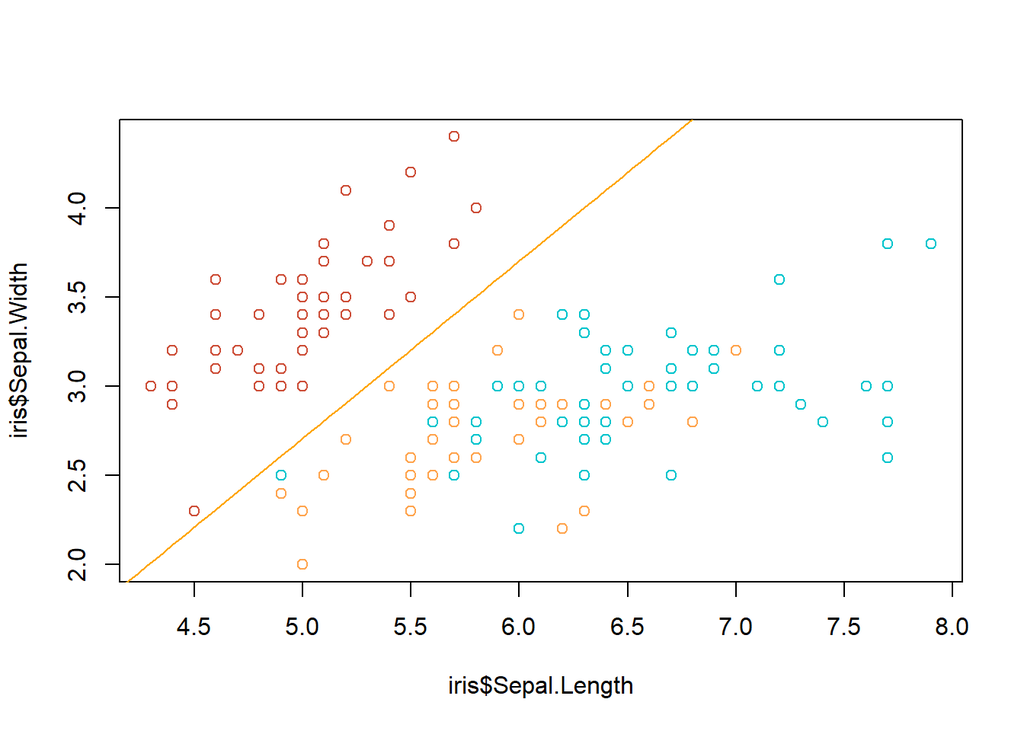

```r
betas <- coef(logitFit)

b1 <- -(betas[1]/betas[5]) #equation of the line via derivation above
m1 <- -(betas[3]/betas[5])

plot(x=iris$Sepal.Length, y=iris$Sepal.Width, col=speciesColour)
curve(m1*x+b1, from=4.0, to=8.0, col="orange",add=TRUE)
```

Recall that versicolor is the tan coloured group and setosa (the “base” class in logistic regression) is the tomato coloured group. We can also plot the decision boundary that discriminates between the virginica and setosa groups. Using a similar derivation as above, the equation for this line is:
$$sepal\:width=-\frac{\beta_{2,0}}{\beta_{2,2}}-\frac{\beta_{2,1}}{\beta_{2,2}}(sepal\:length)$$

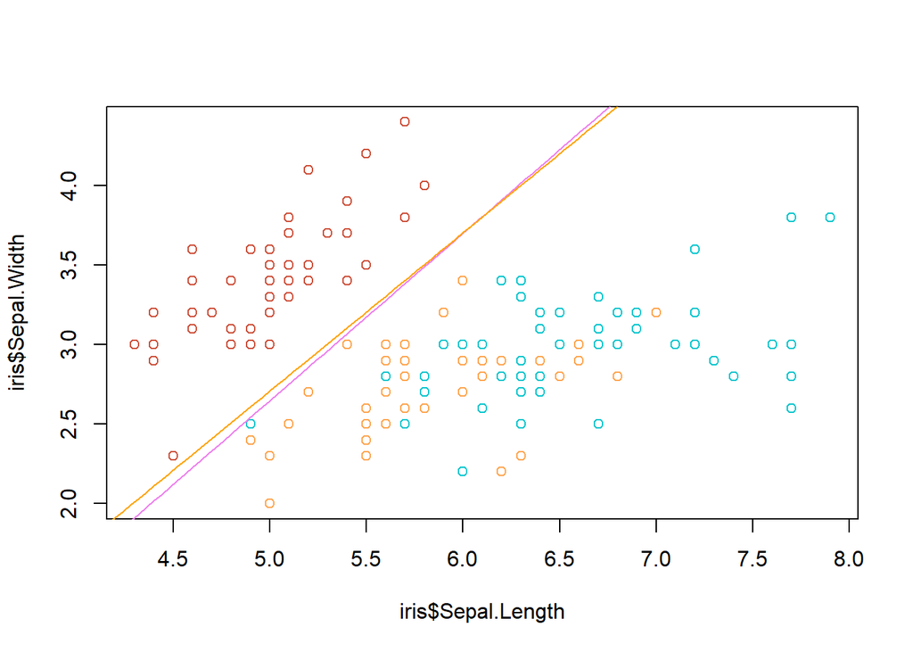

```r
b2 <- -(betas[2]/betas[6])
m2 <- -(betas[4]/betas[6])

plot(x=iris$Sepal.Length, y=iris$Sepal.Width, col=speciesColour)
curve(m2*x+b2, from=4.0, to=8.0, col="violet",add=TRUE)
curve(m1*x+b1, from=4.0, to=8.0, col="orange",add=TRUE)
```

There is one last decision boundary that must be plotted. It is the boundary that separates the versicolor group with the virginica group. The derivation for the equation for this decision boundary is more involved. First, we need to expresses the probabilities $Pr(G=versicolor\:|X=x)$ and $Pr(G=virginica\:|X=x)$:
$$Pr(G=versicolor\:|X=x)=\frac{exp(\beta_{1,0}+\beta_1^Tx)}{1+exp(\beta_{1,0}+\beta_1^Tx)+exp(\beta_{2,0}+\beta_2^Tx)}$$

The shorthand $x$ above is equivalent to $\begin{bmatrix}sepal\:length \\ sepal\:width \end{bmatrix}$.

Likewise we can represent $Pr(G=virginica\:|X=x)$ as follows:
$$Pr(G=virginica\:|X=x)=\frac{exp(\beta_{2,0}+\beta_2^Tx)}{1+exp(\beta_{1,0}+\beta_1^Tx)+exp(\beta_{2,0}+\beta_2^Tx)}$$

This can be transformed into the “log odds” ratio (a monotone increasing transformation) as follows:
$$log\frac{Pr(G=versicolor\:|X=x)}{Pr(G=virginica\:|X=x)}=log\frac{exp(\beta_{1,0}+\beta_1^Tx)}{exp(\beta_{2,0}+\beta_2^Tx)}=\beta_{1,0}+\beta_1^Tx-(\beta_{2,0}+\beta_2^Tx)$$

Note that on the decision boundary, $Pr(G=versicolor|X=x)=Pr(G=verginica|X=x)$ and so the above equation simplifies to the following:
$$0=(\beta_{1,0}-\beta_{2,0})+\beta_{1,1}(sepal\:length)+\beta_{1,2}(sepal\:width)-\beta_{2,1}(sepal\:length)-\beta_{2,2}(sepal\:width)$$

Finally with some simplification, we can arrive at the equation of a line that can be plotted in R:
$$(sepal\:width)=\frac{\beta_{1,0}-\beta_{2,0}}{\beta_{2,2}-\beta_{1,2}}+\frac{\beta_{1,1}-\beta_{2,1}}{\beta_{2,2}-\beta_{1,2}}(sepal\:length)$$

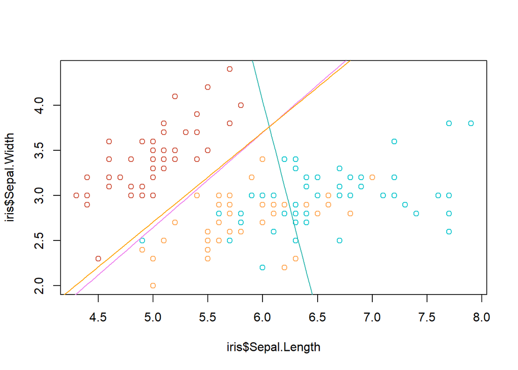

```r
b3 <- (betas[1]-betas[2])/(betas[6]-betas[5])
m3 <- (betas[3]-betas[4])/(betas[6]-betas[5])

plot(x=iris$Sepal.Length, y=iris$Sepal.Width, col=speciesColour)
curve(m3*x+b3, from=4.0, to=8.0, col="lightseagreen", add=TRUE)
curve(m2*x+b2, from=4.0, to=8.0, col="violet", add=TRUE)
curve(m1*x+b1, from=4.0, to=8.0, col="orange", add=TRUE)
```

The coefficients from logistic regression can also be used to model the probability of belonging to each class directly. We can examine the model for the probability of belonging to the $setosa$ class below:

$$Pr(G=setosa\:|X=x)=\frac{1}{1+\sum_{i=1}^{K-1}exp(\beta_{i,0}+\beta_{i}^Tx)}$$

In the above equation, K is the total number of classes. To visualize this probability function, there are a few considerations. In two dimensions, it only makes sense to visualize how the probability function changes when all other variables are fixed.

We arbitrarily can choose the mean value for $sepal\:width$. In the $sepal\:length$ variable, the separation is largest in the $setosa$ class so we will to examine this class.

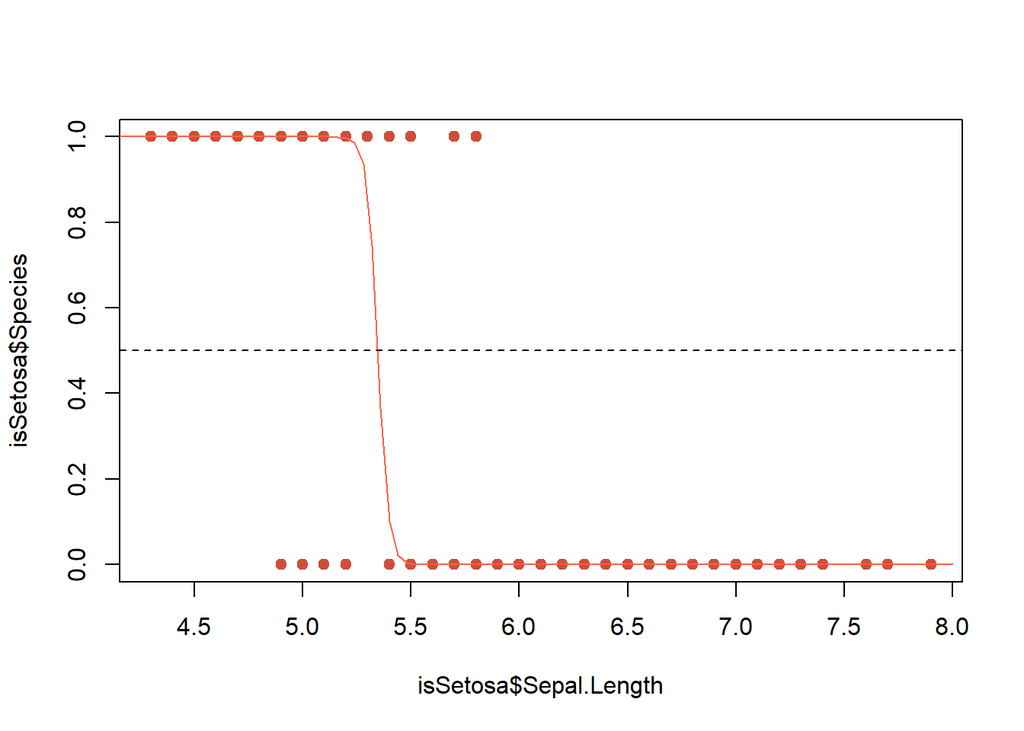

```r
isSetosa <- iris[,c(1,5)]
isSetosa$Species <- ifelse(isSetosa$Species=="setosa", y=1, n=-0) #indicator vector

y <- mean(iris$Sepal.Width)

plot(x=isSetosa$Sepal.Length, y=isSetosa$Species, col="tomato3", pch=19)
curve(1/(1+exp(betas[1]+betas[3]*x+betas[5]*y)+exp(betas[2]+betas[4]*x+betas[6]*y)),
      from=4.0, to=8.0, col="tomato", add=TRUE)
abline(h=0.5, lty=2)
```

Note that where the probability function (the logistic regression curve) intersects the line $y=0.5$ should be the same location as the decision boundary $Pr(G=setosa\:|X=x)=0.5$ when the $sepal\:width$ is the mean $sepal\:width$. This problem is difficult to solve analytically:

$$0.5=\frac{1}{1+\sum_{i=1}^{K-1}exp(\beta_{i,0}+\beta_{i}^Tx)}$$

We can try to solve this problem approximately:

```r
eq <- function(x){
  1/(1+exp(betas[1]+betas[3]*x+betas[5]*y)+exp(betas[2]+betas[4]*x+betas[6]*y))
}

for (i in seq(from=4, to=8, 0.001)){
  if(eq(i)>=0.49 & eq(i)<=0.51){
    print(i)
  }
}
```

```
## [1] 5.346
## [1] 5.347
```

Therefore the decision boundary is at $x\approx 5.34$. We can plot this on the probability function:

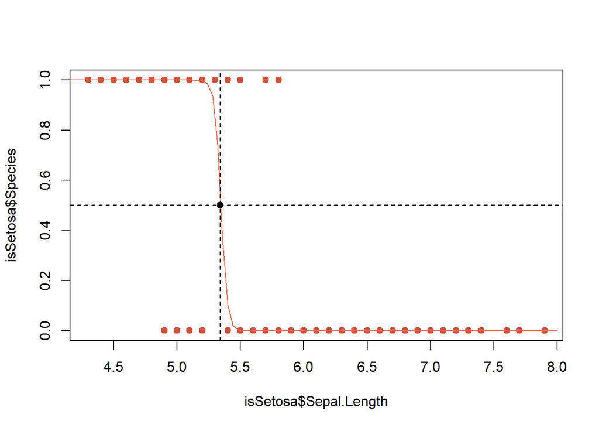

```r
plot(x=isSetosa$Sepal.Length, y=isSetosa$Species, col="tomato3", pch=19)
curve(1/(1+exp(betas[1]+betas[3]*x+betas[5]*y)+exp(betas[2]+betas[4]*x+betas[6]*y)),
      from=4.0, to=8.0, col="tomato", add=TRUE)
abline(h=0.5, lty=2)
abline(v=5.34, lty=2)
points(x=5.34, y=0.5, pch=19)
```

This same point can be plotted in two variables. Recall that the choice of $sepal\:width$ was the mean $sepal\:width$:

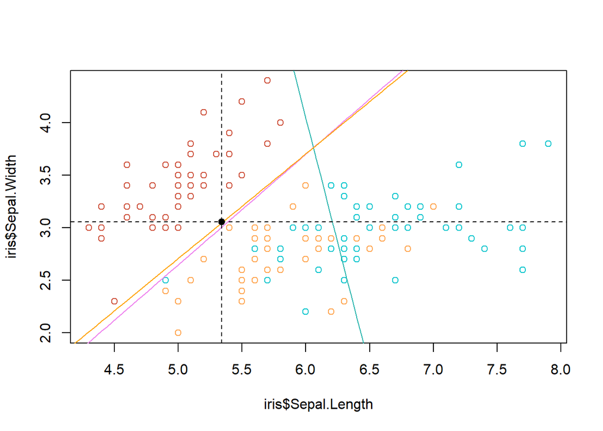

```r
msw <- mean(iris$Sepal.Width)

#the same plot as before
plot(x=iris$Sepal.Length, y=iris$Sepal.Width, col=speciesColour)
curve(m3*x+b3, from=4.0, to=8.0, col="lightseagreen", add=TRUE)
curve(m2*x+b2, from=4.0, to=8.0, col="violet", add=TRUE)
curve(m1*x+b1, from=4.0, to=8.0, col="orange", add=TRUE)

#information from the probability function
abline(h=msw, v=5.34, lty=2)
points(x=5.34, y=msw, pch=19)
```

Note that this point falls on the decision boundary as expected.

Another question is how these boundaries would change if we wanted to see where the probability of belonging to one class was twice as large as belonging to any other class? Note that our equation for the first boundary would change as follows:

$$log2=\beta_{1,0}+\begin{bmatrix}\beta_{1,1} & \beta_{1,2}\end{bmatrix}\begin{bmatrix}sepal\:length \\ sepal\:width \end{bmatrix}$$

The equation of the line changes in this way:

$$sepal\:width=-\frac{\beta_{1,0}-log2}{\beta_{1,2}}-\frac{\beta_{1,1}}{\beta_{1,2}}(sepal\:length)$$

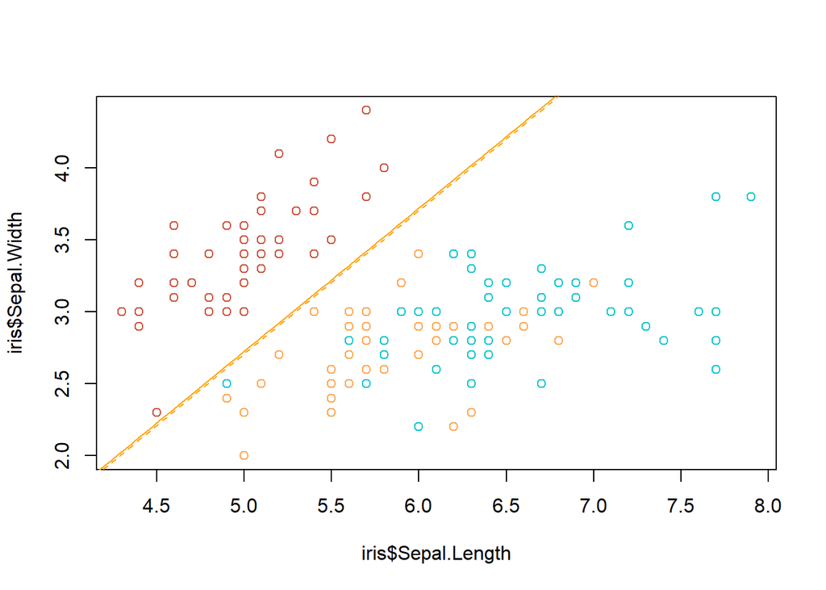

```r
#note that only the intercept changes
plot(x=iris$Sepal.Length, y=iris$Sepal.Width, col=speciesColour)
curve(m1*x+b1-log(2)/betas[5], from=4.0, to=8.0, col="orange", add=TRUE)
curve(m1*x+b1, from=4.0, to=8.0, col="orange", lty=2, add=TRUE)
```

These lines are so close to each other because of the probability function for the $setosa$ class. In a small range of $sepal\:length$, the probability of belonging to the setosa class goes from $0$ to $1$. The decision boundary is “sharp”. Meaning that a small change in $sepal\:length$ (for constant $sepal\:width$) results in a large change in probability.

However, the separation between the $versicolor$ and $virginica$ class is less separable, so we expect the decision boundary to be more sensitive to probability thresholds. This can also be shown mathematically:

$$log2=(\beta_{1,0}-\beta_{2,0})+\beta_{1,1}(sepal\:length)+\beta_{1,2}(sepal\:width)-\beta_{2,1}(sepal\:length)-\beta_{2,2}(sepal\:width)$$

Finally with some simplification, we can arrive at the equation of a line that can be plotted in R:
$$(sepal\:width)=\frac{\beta_{1,0}-\beta_{2,0}-log2}{\beta_{2,2}-\beta_{1,2}}+\frac{\beta_{1,1}-\beta_{2,1}}{\beta_{2,2}-\beta_{1,2}}(sepal\:length)$$

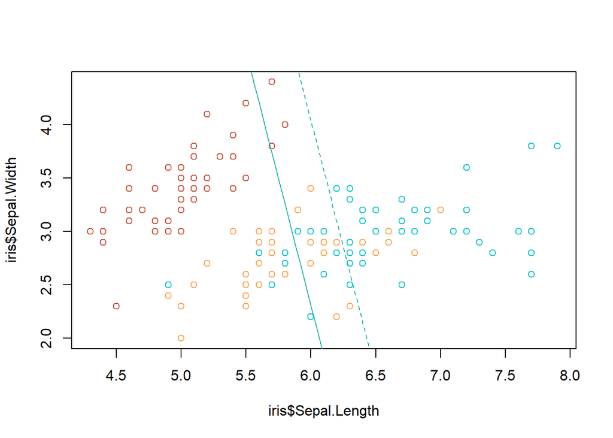

```r
plot(x=iris$Sepal.Length, y=iris$Sepal.Width, col=speciesColour)
curve(m3*x+b3-log(2)/(betas[6]-betas[5]), from=4.0, to=8.0, col="lightseagreen", add=TRUE)
curve(m3*x+b3, from=4.0, to=8.0, col="lightseagreen", lty=2, add=TRUE)
```

From the previous mathematical formulation for the equation of the line representing the decision boundary, it is interesting to note that changes in the probability threshold affect only the intercept of the line and not the slope.

**1.2. Linear Discriminant Analysis Decision Boundaries**

The decision boundaries that result from linear discriminant analysis and logistic regression should be similar. Both classifiers generate a linear decision boundary that separates the $log$ of the probability ratio of belonging to one class over the base class:

$$log\frac{Pr(G=k|X=x)}{Pr(G=l|X=x)}=log\frac{\pi_k}{\pi_l}-\frac{1}{2}(\mu_k+\mu_l)^T\Sigma^{-1}(\mu_k-\mu_l)+x^T\Sigma^{-1}(\mu_k-\mu_l)$$

Where $\pi_i$ represents the prior probability of belonging to the $ith$ class (determined from the distribution of classes in the training data).

```r
library(MASS)
#again, we will restrict the scope to 2 variables
ldaFit <- lda(x=iris[,-c(3:5)], grouping=iris$Species)
ldaFit
```

```
## Call:
## lda(iris[, -c(3:5)], grouping = iris$Species)
##
## Prior probabilities of groups:
##     setosa versicolor  virginica
##  0.3333333  0.3333333  0.3333333
##
## Group means:
##            Sepal.Length Sepal.Width
## setosa            5.006       3.428
## versicolor        5.936       2.770
## virginica         6.588       2.974
##
## Coefficients of linear discriminants:
##                    LD1        LD2
## Sepal.Length -2.141178 -0.8152721
## Sepal.Width   2.768109 -2.0960764
##
## Proportion of trace:
##    LD1    LD2
## 0.9628 0.0372
```

The $lda$ function outputs all of the relevant values to compute the decision boundary, but we need to compute the variance-covariance matrix $\hat{\Sigma}=\sum_{k=1}^K\Sigma_{g_i=k}(x_i-\hat{\mu}_k)(x_i-\hat{\mu}_k)^T/(N-K)$.

```r
setosaGroup <- as.matrix(iris[which(iris$Species=="setosa"),-c(3:5)]) #restricting to 2 variables -c(3:5)
versicolorGroup <- as.matrix(iris[which(iris$Species=="versicolor"),-c(3:5)])
virginicaGroup <- as.matrix(iris[which(iris$Species=="virginica"),-c(3:5)])

#for readability, replace the sweep function with a custom function
xMinusMu_k <- function(x){
  sweep(x=x, MARGIN=2, STATS=colMeans(x))
}

innerSumSetosa <- t(xMinusMu_k(setosaGroup))%*%xMinusMu_k(setosaGroup)
innerSumVersicolor <- t(xMinusMu_k(versicolorGroup))%*%xMinusMu_k(versicolorGroup)
innerSumVirginica <- t(xMinusMu_k(virginicaGroup))%*%xMinusMu_k(virginicaGroup)

sigma <- (innerSumSetosa+innerSumVersicolor+innerSumVirginica)/(nrow(iris)-3)
sigmaInverse <- solve(sigma)
```

Now to get the equation of the decision boundary in the form of the equation of a line as before, we have to rearrange the log ratio from before. Note that at the decision boundary, $Pr(G=k|X=x)=Pr(G=l|X=x)$. Note the (partial) substitutions for $\Sigma^{-1}$ and $\mu_k-\mu_l$. The algebraic manipulations to come will be difficult to understand without them:

$$log1=log\frac{\pi_k}{\pi_l}-\frac{1}{2}(\mu_k+\mu_l)^T\Sigma^{-1}(\mu_k-\mu_l)+\begin{bmatrix}sepal\:length & sepal\:width \end{bmatrix}\begin{bmatrix}\sigma_{1,1}^{-1} && \sigma_{1,2}^{-1} \\\sigma_{2,1}^{-1} && \sigma_{2,2}^{-1}\end{bmatrix}\begin{bmatrix}\mu_k^{SL}-\mu_l^{SL} \\ \mu_k^{SW}-\mu_l^{SW} \end{bmatrix}$$

$$0=\biggr(log\frac{\pi_k}{\pi_l}-\frac{1}{2}(\mu_k+\mu_l)^T\Sigma^{-1}(\mu_k-\mu_l)\biggr)+\begin{bmatrix}SL\sigma_{1,1}^{-1}+SW\sigma_{2,1}^{-1} && SL\sigma_{1,2}^{-1}+SW\sigma_{2,2}^{-1}\end{bmatrix}\begin{bmatrix}\mu_k^{SL}-\mu_l^{SL} \\ \mu_k^{SW}-\mu_l^{SW} \end{bmatrix}$$

$$0=log\frac{\pi_k}{\pi_l}-\frac{1}{2}(\mu_k+\mu_l)^T\Sigma^{-1}(\mu_k-\mu_l)+(SL\sigma_{1,1}^{-1}+SW\sigma_{2,1}^{-1})(\mu_k^{SL}-\mu_l^{SL})+ (SL\sigma_{1,2}^{-1}+SW\sigma_{2,2}^{-1})(\mu_k^{SW}-\mu_l^{SW})$$

Finally, this gives:
$$SW=\frac{log\frac{\pi_k}{\pi_l}-\frac{1}{2}(\mu_k+\mu_l)^T\Sigma^{-1}(\mu_k-\mu_l)}{\sigma_{2,1}^{-1}(\mu_l^{SL}-\mu_k^{SL})+\sigma_{2,2}^{-1}(\mu_l^{SW}-\mu_k^{SW})}+SL\frac{\sigma_{1,1}^{-1}(\mu_k^{SL}-\mu_l^{SL})+\sigma_{1,2}^{-1}(\mu_k^{SW}-\mu_l^{SW})}{\sigma_{2,1}^{-1}(\mu_l^{SL}-\mu_k^{SL})+\sigma_{2,2}^{-1}(\mu_l^{SW}-\mu_k^{SW})}$$

```r
denominator1 <- sigmaInverse[2,1]*(ldaFit$means[2,1]-ldaFit$means[1,1]) +
  sigmaInverse[2,2]*(ldaFit$means[2,2]-ldaFit$means[1,2])

numerator1 <- sigmaInverse[1,1]*(ldaFit$means[1,1]-ldaFit$means[2,1]) +
  sigmaInverse[1,2]*(ldaFit$means[1,2]-ldaFit$means[2,2])

mLda1 <- numerator1/denominator1
bLda1 <- -0.5*t(ldaFit$means[1,]+ldaFit$means[2,])%*%sigmaInverse%*%(ldaFit$means[1,]-ldaFit$means[2,])/denominator1

#calculations for the other 2 decision boundaries are hidden for simplicity
```

The boundaries generated by linear discriminant analysis can be interpreted as being a function of the distance from the group means of each class. To visualize this, group means have been plotted along with the decision boundaries calculated above.

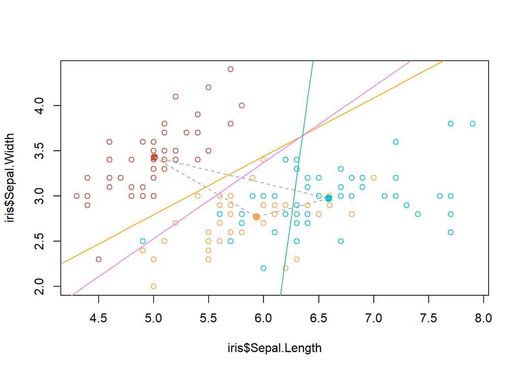

```r
plot(x=iris$Sepal.Length, y=iris$Sepal.Width, col=speciesColour)
curve(mLda1*x+bLda1[1], from=4.0, to=8.0, col="orange", add=TRUE)
curve(mLda2*x+bLda2[1], from=4.0, to=8.0, col="violet", add=TRUE)
curve(mLda3*x+bLda3[1], from=4.0, to=8.0, col="lightseagreen", add=TRUE)

points(ldaFit$means, pch=19, cex=1.25, col=c("tomato3","tan1","turquoise3"))
connectMeans <- rbind(ldaFit$means, ldaFit$means[1,])
lines(connectMeans, lty=2, col="darkgrey")
```

It is apparent that the decision boundaries are the lines exactly equidistant between any given pair of group means. However, these lines are not perpendicular to the lines connecting any pair of group means. This is because the covariance matrix is not spherical i.e. $\sigma^2\textbf{I}$.

These boundaries from linear discriminant analysis can also be projected on the $K-1$ dimensional subspace defined by the LDA canoncial variables to show more clearly the minimized within-class variance and maximized between-class variance.

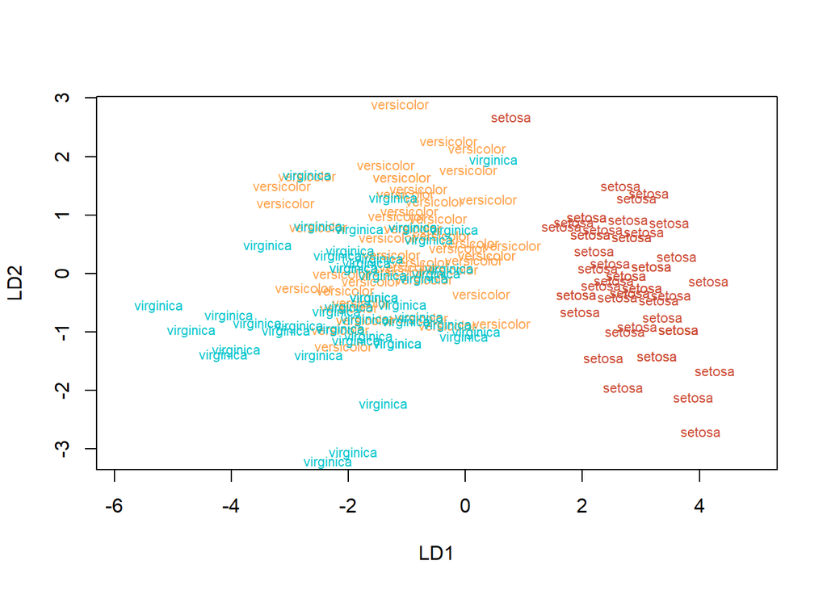

```r
#the built-in plot function in R does exactly the above
plot(ldaFit, col=speciesColour)
```

The separation between classes in this new subspace isn’t much better than in the original variables (visually). We can revert back to the more meaningful variables going forward and avoid losing interpretability.

Like before, the decision boundaries were derived from class posterior probabilities given by Bayes rule:
$$Pr(G=k|X=x)=\frac{f_k(x)\pi_k}{\sum_{l=1}^Kf_l(x)\pi_l}$$

Under the assumption of multivariate Gaussian class-conditional densities, with class-prior probability $\pi_i$, and a common between-class covariance matrix $\Sigma$, this gives:
$$Pr(G=k|X=x)=\frac{\frac{1}{(2\pi)^\frac{p}{2}|\Sigma|^\frac{1}{2}}e^{-\frac{1}{2}(x-\mu_k)^T\Sigma^{-1}(x-\mu_k)}\pi_k}{\sum_{l=1}^K\frac{1}{(2\pi)^\frac{p}{2}|\Sigma|^\frac{1}{2}}e^{-\frac{1}{2}(x-\mu_l)^T\Sigma^{-1}(x-\mu_l)}\pi_l}$$

Note that the coefficient terms cancel out, and in our case the class-priors are equal.

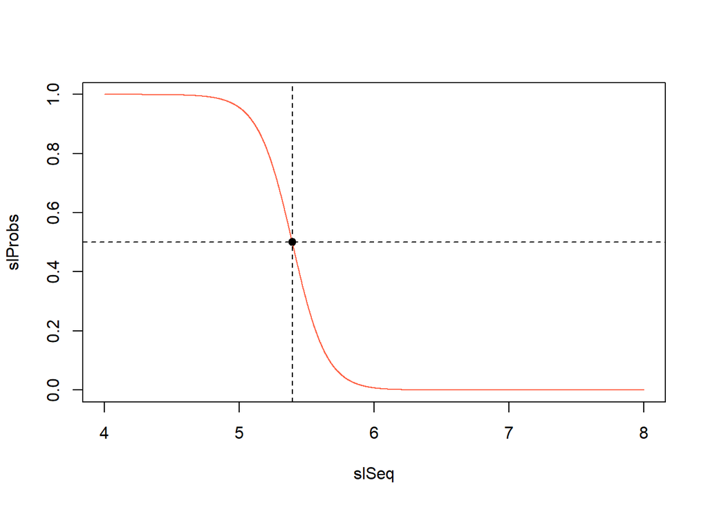

```r
#recall from before that y is the mean sepal width

fx <- function(x){ #normalization factors & priors can be factored out and cancelled (equal b/w classes)
  num <- exp(-0.5*t(c(x,y)-colMeans(setosaGroup))%*%sigmaInverse%*%(c(x,y)-colMeans(setosaGroup)))
  den <- exp(-0.5*t(c(x,y)-colMeans(setosaGroup))%*%sigmaInverse%*%(c(x,y)-colMeans(setosaGroup))) +
    exp(-0.5*t(c(x,y)-colMeans(versicolorGroup))%*%sigmaInverse%*%(c(x,y)-colMeans(versicolorGroup))) +
    exp(-0.5*t(c(x,y)-colMeans(virginicaGroup))%*%sigmaInverse%*%(c(x,y)-colMeans(virginicaGroup)))
  num/den
}

slSeq <- seq(4.0,8.0,0.001)
slProbs <- lapply(slSeq,fx)

sl <- slSeq[which(slProbs>=0.499 & slProbs <= 0.501)] #where does probability = 0.5 (w/ tolerance)

plot(x=slSeq, y=slProbs, type="l", col="tomato") #probability function
abline(h=0.5, v=sl, lty=2)
points(x=sl, y=0.5, pch=19)
```

Like in logistic regression, we can now visualize this as a point on the decision boundary:

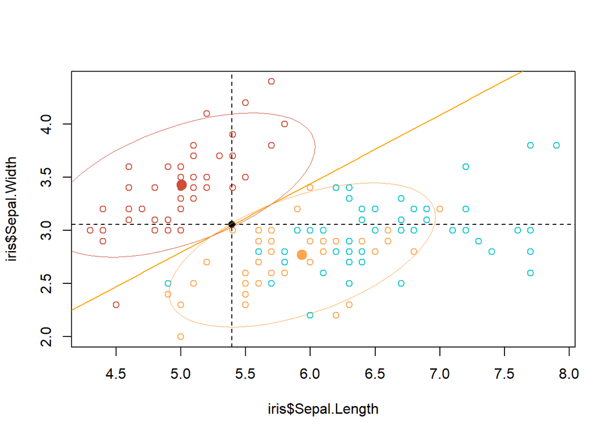

```r
plot(x=iris$Sepal.Length, y=iris$Sepal.Width, col=speciesColour)
curve(mLda1*x+bLda1[1], from=4.0, to=8.0, col="orange", add=TRUE)

#information from the probability function
abline(v=sl, h=y, lty=2)
points(x=sl, y=y, pch=19)

library(car)
ellipse(center=ldaFit$means[1,], shape=sigma, radius=2, col="tomato3", lwd=0.75)
ellipse(center=ldaFit$means[2,], shape=sigma, radius=2, col="tan1", lwd=0.75)
```

Note that in the above figure the shape of the class-conditional Gaussian distributions are also plotted for additional information. Again, in this setup all classes share the same variance-covariance matrix $\Sigma$.

In the (visually noisy) figure below, the linear discriminant analysis decision boundaries are plotted using a solid line and the decision boundaries for logistic regression are plotted using a dashed line for comparison:

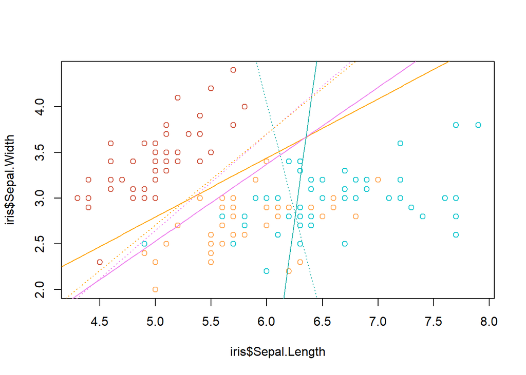

```r
plot(x=iris$Sepal.Length, y=iris$Sepal.Width, col=speciesColour)
curve(mLda1*x+bLda1[1], from=4.0, to=8.0, col="orange", add=TRUE)
curve(mLda2*x+bLda2[1], from=4.0, to=8.0, col="violet", add=TRUE)
curve(mLda3*x+bLda3[1], from=4.0, to=8.0, col="lightseagreen", add=TRUE)

curve(m3*x+b3, from=4.0, to=8.0, col="lightseagreen", lty=3, add=TRUE)
curve(m2*x+b2, from=4.0, to=8.0, col="violet", lty=3, add=TRUE)
curve(m1*x+b1, from=4.0, to=8.0, col="orange", lty=3, add=TRUE)
```

Interestingly, just like in logistic regression we can see from the mathematical formulation of the decision boundary for linear discriminant analysis that changes in either prior probabilities or probability thresholds change only the intercept of the equation for the line and not the slope.

The behaviour for both models is slightly different. We can intuitively understand this because the decision boundary in linear discriminant analysis is calculated based on the distance between group means. The logistic regression function tries to achieve the best separation between groups by finding a “group boundary” instead.